# RandomForest

Cassandra Sperow

2023-11-09

# Experimental Random Forest Modeling of Clade C Coral Data

- Logistic regression has proven to not be a good method of modeling the CLade C data. The data are inherently non-linear and the ASVs have many dependencies presenting multicollinearity.
- To obtain an index of the ASVs or variables that define Clade C the most, a non-parametric method such as RandomForest is useful and allows for interpretability of the model with its outut of an importance list.

## Read in Clade C and Non-Clade C Balanced dataset with CLR-Transformed ASV data

- The lr_clr_df_2.csv file also inlcudes other variables such as species and region

```r
read_csv("../output/lr_clr_df_2.csv") %>%
  mutate(ITS2_type = as.factor(ITS2_type),
         Clade = as.factor(Clade)) -> df
```

- Need to take out the ITS2 Type as this would be defining Clade C and would be highly correlated.

```r
library(randomForest)
set.seed(123)
BAG_t <- randomForest(Clade ~ . ,
                     data = df[,-c(1,3)])

BAG_t
```

```
##
## Call:
##  randomForest(formula = Clade ~ ., data = df[, -c(1, 3)])
##                Type of random forest: classification
##                      Number of trees: 500
## No. of variables tried at each split: 56
##
##         OOB estimate of  error rate: 29.14%
## Confusion matrix:
##    0   1 class.error
## 0 94  45   0.3237410
## 1 36 103   0.2589928
```

- Error in having so many categories with ITS2 type; removing to re-run model.
- With taking out the ITS2 type column and the sample ID column, the random forest model gives an error rate of about 29 % overall.

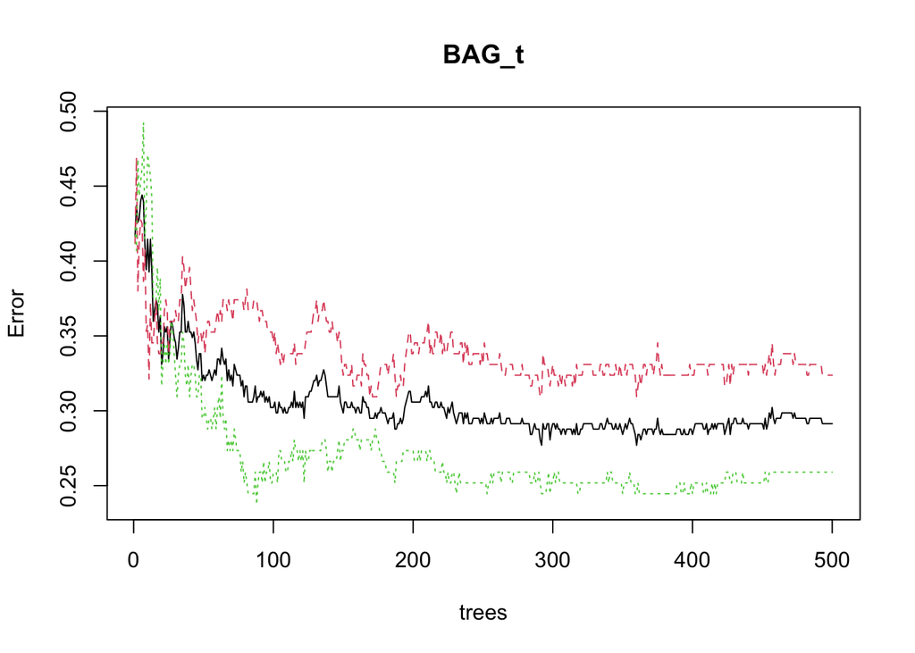

```r
base::plot(BAG_t)
```

```r
BAG_t$err.rate[which.min(BAG_t$err.rate)]
```

```
## [1] 0.2374101
```

```r
############################## optimal number of trees
(BAG_t$err.rate |> as.data.frame())$OOB |> which.min() # 292 trees
```

```
## [1] 292
```

```r
############################## find optimal mtry
set.seed(3)
# training set
Zt <- sample(nrow(df), .8*nrow(df))
tuneRF(df[Zt,-c(1,3)], df[Zt,]$Clade, mtryStart = 2) #
```

```
## mtry = 2  OOB error = 42.34%
## Searching left ...
## mtry = 1     OOB error = 50.9%
## -0.2021277 0.05
## Searching right ...
## mtry = 4     OOB error = 35.14%
## 0.1702128 0.05
## mtry = 8     OOB error = 32.88%
## 0.06410256 0.05
## mtry = 16    OOB error = 32.43%
## 0.01369863 0.05
```

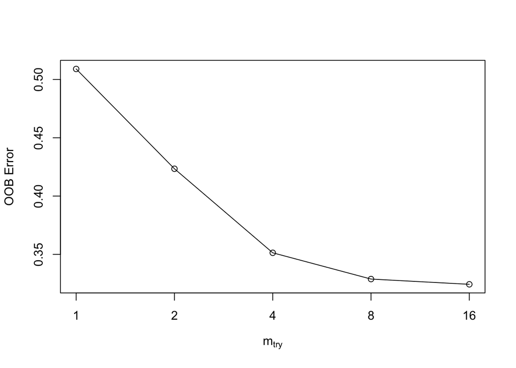

```
##        mtry  OOBError
## 1.OOB     1 0.5090090
## 2.OOB     2 0.4234234
## 4.OOB     4 0.3513514
## 8.OOB     8 0.3288288
## 16.OOB   16 0.3243243
```

## Re-run with Optimal Number of Trees and ‘mtry’ Splits

```r
set.seed(123)
BAG_8 <- randomForest(Clade ~ . ,
                     data = df[,-c(1,3)],
                     mtry = 8,
                     ntree = 292)

BAG_8
```

```
##
## Call:
##  randomForest(formula = Clade ~ ., data = df[, -c(1, 3)], mtry = 8,      ntree = 292)
##                Type of random forest: classification
##                      Number of trees: 292
## No. of variables tried at each split: 8
##
##         OOB estimate of  error rate: 32.73%
## Confusion matrix:
##    0   1 class.error
## 0 86  53   0.3812950
## 1 38 101   0.2733813
```

```r
importance(BAG_8) %>%
  as.data.frame() %>%
  arrange(-MeanDecreaseGini)
```

```
##            MeanDecreaseGini
## its2_count     3.239346e+00
## ASV0016        7.228449e-01
## ASV0050        6.182127e-01
## ASV0168        5.814448e-01
## ASV0013        5.523861e-01
## region         5.198973e-01
## ASV0208        4.236337e-01
## ASV0014        4.156864e-01
## ASV0066        3.887491e-01
## ASV0082        3.845859e-01
## ASV0104        3.761231e-01
## ASV0185        3.705181e-01
## ASV0148        3.629697e-01
## ASV0002        3.466771e-01
## ASV0027        3.412704e-01
## ASV0003        3.378521e-01
## ASV0300        3.150225e-01
## ASV0059        3.101343e-01
## ASV0177        3.028891e-01
## ASV0018        3.004218e-01
## ASV0004        2.997804e-01
## ASV0074        2.983326e-01
## ASV0022        2.929768e-01
## ASV0072        2.903796e-01
## ASV0070        2.889353e-01
## ASV0053        2.829800e-01
## ASV0499        2.754807e-01
## ASV0020        2.742847e-01
## ASV0025        2.735743e-01
## ASV0552        2.685832e-01
## ASV0289        2.683971e-01
## ASV0129        2.622976e-01
## ASV0058        2.615071e-01
## ASV0198        2.602708e-01
## ASV0172        2.598616e-01
## ASV0010        2.596414e-01
## ASV0165        2.460531e-01
## ASV0157        2.450595e-01
## ASV0549        2.446282e-01
```

[output cut: 3175 more lines]

```
## ASV4545        0.000000e+00
## ASV4710        0.000000e+00
## ASV13469       0.000000e+00
## ASV4363        0.000000e+00
## ASV6017        0.000000e+00
## ASV0917        0.000000e+00
## ASV11218       0.000000e+00
## ASV11229       0.000000e+00
## ASV11604       0.000000e+00
## ASV2165        0.000000e+00
## ASV2340        0.000000e+00
## ASV3738        0.000000e+00
## ASV5084        0.000000e+00
## ASV9614        0.000000e+00
## ASV16068       0.000000e+00
```

### Try again without the ITS2 count as it would also be highly correlated with Clade C.

```r
library(randomForest)
set.seed(123)
BAG_t <- randomForest(Clade ~ . ,
                     data = df[,-c(1,3:4)])

BAG_t
```

```
##
## Call:
##  randomForest(formula = Clade ~ ., data = df[, -c(1, 3:4)])
##                Type of random forest: classification
##                      Number of trees: 500
## No. of variables tried at each split: 56
##
##         OOB estimate of  error rate: 37.41%
## Confusion matrix:
##    0  1 class.error
## 0 79 60   0.4316547
## 1 44 95   0.3165468
```

- The error rate increases rather than decreases when ITS2 count is taken out.

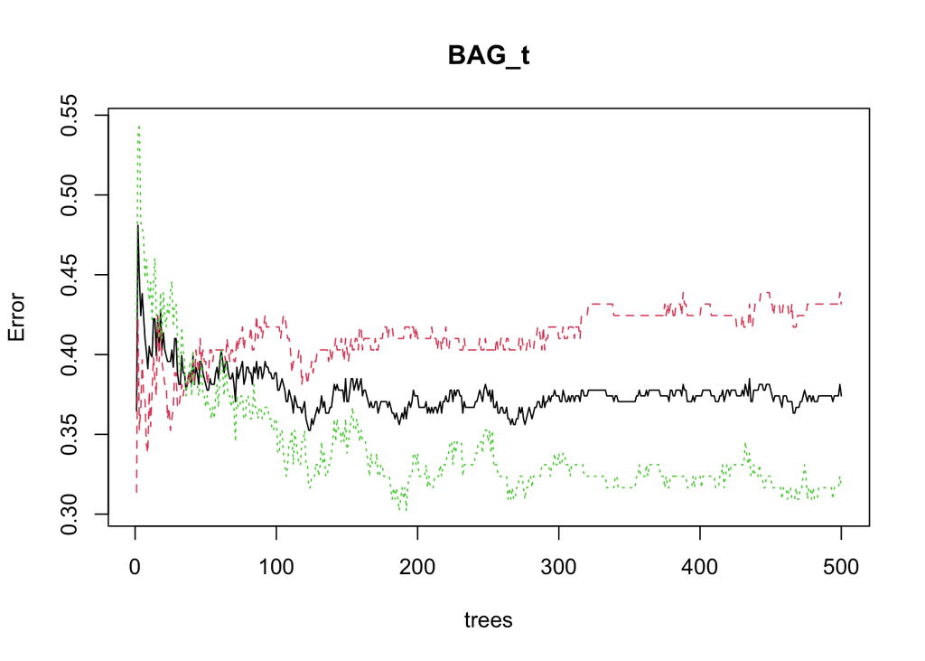

```r
base::plot(BAG_t)
```

- Seems a lot less stable

```r
BAG_t$err.rate[which.min(BAG_t$err.rate)]
```

```
## [1] 0.3021583
```

- Error rate does not improve

```r
############################## optimal number of trees
(BAG_t$err.rate |> as.data.frame())$OOB |> which.min() # 123 trees
```

```
## [1] 123
```

```r
############################## find optimal mtry
set.seed(3)
# training set
Zt <- sample(nrow(df), .8*nrow(df))
tuneRF(df[Zt,-c(1,3:4)], df[Zt,]$Clade, mtryStart = 2) #
```

```
## mtry = 2  OOB error = 45.95%
## Searching left ...
## mtry = 1     OOB error = 57.21%
## -0.245098 0.05
## Searching right ...
## mtry = 4     OOB error = 35.14%
## 0.2352941 0.05
## mtry = 8     OOB error = 36.49%
## -0.03846154 0.05
```

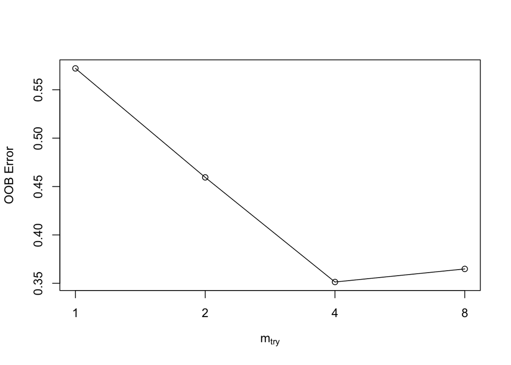

```
##       mtry  OOBError
## 1.OOB    1 0.5720721
## 2.OOB    2 0.4594595
## 4.OOB    4 0.3513514
## 8.OOB    8 0.3648649
```

## Re-run with Optimal Number of Trees and ‘mtry’ Splits

```r
set.seed(123)
BAG_4 <- randomForest(Clade ~ . ,
                     data = df[,-c(1,3:4)],
                     mtry = 4,
                     ntree = 123)

BAG_4
```

```
##
## Call:
##  randomForest(formula = Clade ~ ., data = df[, -c(1, 3:4)], mtry = 4,      ntree = 123)
##                Type of random forest: classification
##                      Number of trees: 123
## No. of variables tried at each split: 4
##
##         OOB estimate of  error rate: 37.05%
## Confusion matrix:
##    0   1 class.error
## 0 70  69   0.4964029
## 1 34 105   0.2446043
```

- The error rate for clade C goes down while the error rate for non-clade c goes up to a coin toss.
- Compare the Importance breakdowns for each model

```r
importance(BAG_4) %>%
  as.data.frame() %>%
  arrange(-MeanDecreaseGini)
```

```
##          MeanDecreaseGini
## ASV0104      5.297755e-01
## region       5.270871e-01
## ASV0185      3.092304e-01
## ASV0099      2.954924e-01
## ASV0477      2.946857e-01
## ASV0020      2.880665e-01
## ASV0444      2.739791e-01
## ASV0013      2.724115e-01
## ASV0050      2.672156e-01
## ASV0295      2.642969e-01
## ASV0082      2.620772e-01
## ASV0009      2.585475e-01
## ASV0019      2.577778e-01
## ASV0066      2.576382e-01
## ASV1331      2.511704e-01
## ASV0016      2.477915e-01
## ASV0058      2.467235e-01
## ASV0479      2.424461e-01
## ASV0112      2.412841e-01
## ASV0208      2.412824e-01
## ASV0157      2.399705e-01
## ASV0005      2.334143e-01
## ASV0675      2.288016e-01
## ASV0061      2.194274e-01
## ASV0800      2.163843e-01
## ASV1434      2.139945e-01
## ASV0014      2.097284e-01
## ASV0065      2.091720e-01
## ASV0062      2.059467e-01
## ASV0279      2.054404e-01
## ASV0003      2.049427e-01
## ASV0596      2.037898e-01
## ASV0165      2.010380e-01
## ASV0346      1.989325e-01
## ASV0187      1.929649e-01
## ASV0072      1.928549e-01
## ASV0687      1.922409e-01
## ASV0168      1.912268e-01
## ASV0313      1.912248e-01
```

[output cut: 3174 more lines]

```
## ASV10584     0.000000e+00
## ASV11218     0.000000e+00
## ASV11604     0.000000e+00
## ASV2165      0.000000e+00
## ASV4012      0.000000e+00
## ASV4094      0.000000e+00
## ASV4454      0.000000e+00
## ASV7031      0.000000e+00
## ASV5084      0.000000e+00
## ASV6584      0.000000e+00
## ASV9614      0.000000e+00
## ASV16068     0.000000e+00
## ASV0395      0.000000e+00
## ASV5640      0.000000e+00
## ASV2854      0.000000e+00
```

```r
## from model with ITS2 count left in
importance(BAG_8) %>%
  as.data.frame() %>%
  arrange(-MeanDecreaseGini)
```

```
##            MeanDecreaseGini
## its2_count     3.239346e+00
## ASV0016        7.228449e-01
## ASV0050        6.182127e-01
## ASV0168        5.814448e-01
## ASV0013        5.523861e-01
## region         5.198973e-01
## ASV0208        4.236337e-01
## ASV0014        4.156864e-01
## ASV0066        3.887491e-01
## ASV0082        3.845859e-01
## ASV0104        3.761231e-01
## ASV0185        3.705181e-01
## ASV0148        3.629697e-01
## ASV0002        3.466771e-01
## ASV0027        3.412704e-01
## ASV0003        3.378521e-01
## ASV0300        3.150225e-01
## ASV0059        3.101343e-01
## ASV0177        3.028891e-01
## ASV0018        3.004218e-01
## ASV0004        2.997804e-01
## ASV0074        2.983326e-01
## ASV0022        2.929768e-01
## ASV0072        2.903796e-01
## ASV0070        2.889353e-01
## ASV0053        2.829800e-01
## ASV0499        2.754807e-01
## ASV0020        2.742847e-01
## ASV0025        2.735743e-01
## ASV0552        2.685832e-01
## ASV0289        2.683971e-01
## ASV0129        2.622976e-01
## ASV0058        2.615071e-01
## ASV0198        2.602708e-01
## ASV0172        2.598616e-01
## ASV0010        2.596414e-01
## ASV0165        2.460531e-01
## ASV0157        2.450595e-01
## ASV0549        2.446282e-01
```

[output cut: 3175 more lines]

```
## ASV4545        0.000000e+00
## ASV4710        0.000000e+00
## ASV13469       0.000000e+00
## ASV4363        0.000000e+00
## ASV6017        0.000000e+00
## ASV0917        0.000000e+00
## ASV11218       0.000000e+00
## ASV11229       0.000000e+00
## ASV11604       0.000000e+00
## ASV2165        0.000000e+00
## ASV2340        0.000000e+00
## ASV3738        0.000000e+00
## ASV5084        0.000000e+00
## ASV9614        0.000000e+00
## ASV16068       0.000000e+00
```

# ASVs Only 1000 from PCA Results for Clade C

## Read in original data with PCA results for Clade C as ordered ASV columns

```r
read_csv( "../output/lr_data.csv") %>%
  mutate(Clade = as.factor(Clade))-> lr_data
head(lr_data)
```

```
## # A tibble: 6 × 3,228
##   sample_id  Clade ASV1236 ASV0421 ASV0691 ASV0899 ASV1004 ASV1041 ASV1058
##   <chr>      <fct>   <dbl>   <dbl>   <dbl>   <dbl>   <dbl>   <dbl>   <dbl>
## 1 SKAU-R2-23 1           0       0       0       0       0       0       0
## 2 SWAJ-R4-3  0           0       0       0       0       0       0       0
## 3 SYAN-R3-19 1           0       0       0       0       0       0       0
## 4 PMAQ-R2-19 0           0       0       0       0       0       0       0
## 5 SDOG-R3-6  0           0       0       0       0       0       0       0
## 6 PDOG-R2-22 0         234     147      90     103      60      42      49
## # ℹ 3,219 more variables: ASV12542 <dbl>, ASV1294 <dbl>, ASV13113 <dbl>,
## #   ASV1318 <dbl>, ASV2269 <dbl>, ASV2542 <dbl>, ASV2660 <dbl>, ASV2737 <dbl>,
## #   ASV2840 <dbl>, ASV3053 <dbl>, ASV3077 <dbl>, ASV3134 <dbl>, ASV3140 <dbl>,
## #   ASV3579 <dbl>, ASV6119 <dbl>, ASV7557 <dbl>, ASV8422 <dbl>, ASV1086 <dbl>,
## #   ASV1310 <dbl>, ASV15750 <dbl>, ASV16905 <dbl>, ASV2033 <dbl>,
## #   ASV2089 <dbl>, ASV2127 <dbl>, ASV2725 <dbl>, ASV2804 <dbl>, ASV3075 <dbl>,
## #   ASV3327 <dbl>, ASV3342 <dbl>, ASV3532 <dbl>, ASV3600 <dbl>, …
```

- The ASV columns are ordered in terms of the PCA results for Clade C from Dimension 1.

### RandomForest 1000 ASVs

- CLR transformation recommended by client and used also in Ridge/Lasso Modeling
- To compare with Ridge/Lasso Modeling, these are the same along with 85 % training data and the format of the data frame.

```r
library(compositions)
lr_data[,1:1002] -> lr_data_1000


bind_cols(lr_data_1000[,1:2],
          lr_data_1000[,-c(1,2)] %>% clr()
            ) -> lr_clr_df_1000

head(lr_clr_df_1000)
```

```
## # A tibble: 6 × 1,002
##   sample_id  Clade ASV1236 ASV0421 ASV0691 ASV0899 ASV1004 ASV1041 ASV1058
##   <chr>      <fct>   <dbl>   <dbl>   <dbl>   <dbl>   <dbl>   <dbl>   <dbl>
## 1 SKAU-R2-23 1        0      0       0       0      0        0       0
## 2 SWAJ-R4-3  0        0      0       0       0      0        0       0
## 3 SYAN-R3-19 1        0      0       0       0      0        0       0
## 4 PMAQ-R2-19 0        0      0       0       0      0        0       0
## 5 SDOG-R3-6  0        0      0       0       0      0        0       0
## 6 PDOG-R2-22 0        1.38   0.913   0.423   0.557  0.0171  -0.340  -0.185
## # ℹ 993 more variables: ASV12542 <dbl>, ASV1294 <dbl>, ASV13113 <dbl>,
## #   ASV1318 <dbl>, ASV2269 <dbl>, ASV2542 <dbl>, ASV2660 <dbl>, ASV2737 <dbl>,
## #   ASV2840 <dbl>, ASV3053 <dbl>, ASV3077 <dbl>, ASV3134 <dbl>, ASV3140 <dbl>,
## #   ASV3579 <dbl>, ASV6119 <dbl>, ASV7557 <dbl>, ASV8422 <dbl>, ASV1086 <dbl>,
## #   ASV1310 <dbl>, ASV15750 <dbl>, ASV16905 <dbl>, ASV2033 <dbl>,
## #   ASV2089 <dbl>, ASV2127 <dbl>, ASV2725 <dbl>, ASV2804 <dbl>, ASV3075 <dbl>,
## #   ASV3327 <dbl>, ASV3342 <dbl>, ASV3532 <dbl>, ASV3600 <dbl>, …
```

```r
library(randomForest)
set.seed(123)
BAG_t_1000 <- randomForest(lr_clr_df_1000$Clade ~ . , # clade is factor
                     data = lr_clr_df_1000[,-c(1,2)], # minus sample id and clade
                     )

BAG_t_1000
```

```
##
## Call:
##  randomForest(formula = lr_clr_df_1000$Clade ~ ., data = lr_clr_df_1000[,      -c(1, 2)], )
##                Type of random forest: classification
##                      Number of trees: 500
## No. of variables tried at each split: 31
##
##         OOB estimate of  error rate: 36.69%
## Confusion matrix:
##    0  1 class.error
## 0 83 56   0.4028777
## 1 46 93   0.3309353
```

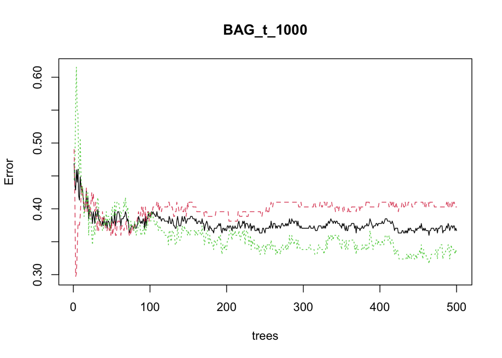

```r
base::plot(BAG_t_1000)
```

```r
############################## optimal number of trees
(BAG_t_1000$err.rate |> as.data.frame())$OOB |> which.min() # 464
```

```
## [1] 464
```

# Tune RF with Training & Testing Split for 1000

```r
############################## find optimal mtry
set.seed(3)
# training set
Z_1000 <- sample(nrow(lr_clr_df_1000), .85*nrow(lr_clr_df_1000)) # same % as lasso/ridge
tuneRF(lr_clr_df_1000[Z_1000,-c(1,2)], # x train minus sample id and clade columns
       lr_clr_df_1000[Z_1000,]$Clade, mtryStart = 2) # y train
```

```
## mtry = 2  OOB error = 41.53%
## Searching left ...
## mtry = 1     OOB error = 45.76%
## -0.1020408 0.05
## Searching right ...
## mtry = 4     OOB error = 41.53%
## 0 0.05
```

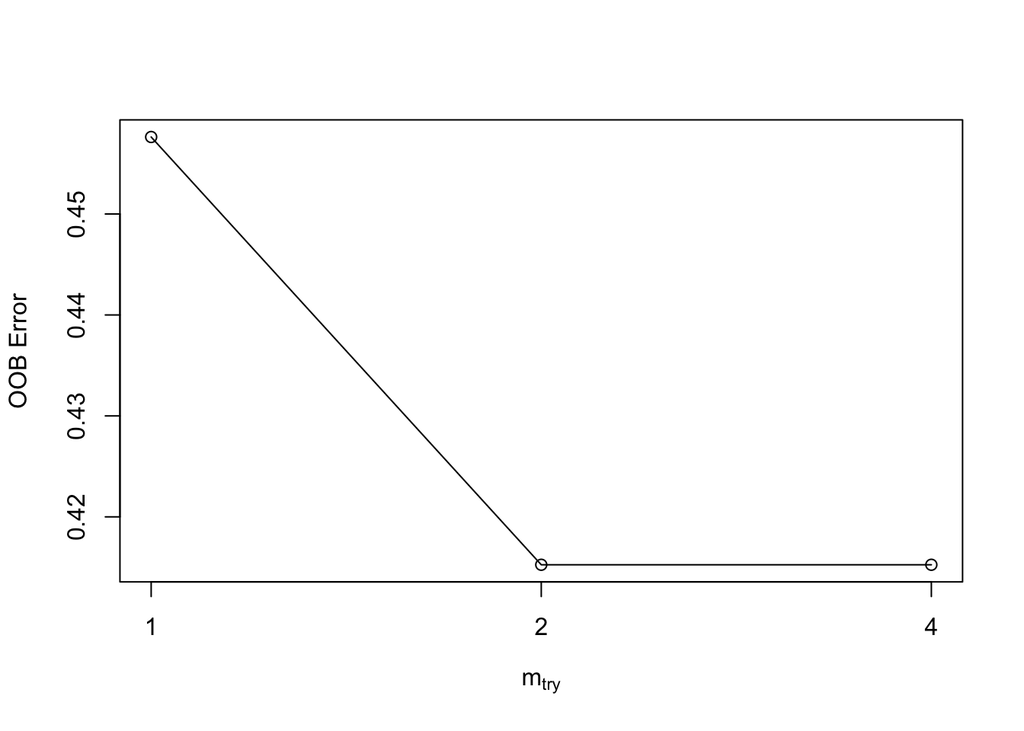

```
##       mtry  OOBError
## 1.OOB    1 0.4576271
## 2.OOB    2 0.4152542
## 4.OOB    4 0.4152542
```

## Re-fit 1000 with optimal ntree and mtry

```r
set.seed(123)
BAG_1000_o <- randomForest(lr_clr_df_1000$Clade ~ . , # clade is already a factor
                     data = lr_clr_df_1000[,-c(1,2)], # minus sample id and clade
                     mtry = 2, # from above tuning
                     ntree = 464) # from above

BAG_1000_o
```

```
##
## Call:
##  randomForest(formula = lr_clr_df_1000$Clade ~ ., data = lr_clr_df_1000[,      -c(1, 2)], mtry = 2, ntree = 464)
##                Type of random forest: classification
##                      Number of trees: 464
## No. of variables tried at each split: 2
##
##         OOB estimate of  error rate: 36.69%
## Confusion matrix:
##    0   1 class.error
## 0 49  90  0.64748201
## 1 12 127  0.08633094
```

## RandomForest 500 ASVs

- Redo CLR transformation

```r
lr_data[,1:502] -> lr_data_500


bind_cols(lr_data_500[,1:2],
          lr_data_500[,-c(1,2)] %>% clr()
            ) -> lr_clr_df_500

head(lr_clr_df_500)
```

```
## # A tibble: 6 × 502
##   sample_id  Clade ASV1236 ASV0421 ASV0691 ASV0899 ASV1004 ASV1041 ASV1058
##   <chr>      <fct>   <dbl>   <dbl>   <dbl>   <dbl>   <dbl>   <dbl>   <dbl>
## 1 SKAU-R2-23 1        0      0       0       0      0        0       0
## 2 SWAJ-R4-3  0        0      0       0       0      0        0       0
## 3 SYAN-R3-19 1        0      0       0       0      0        0       0
## 4 PMAQ-R2-19 0        0      0       0       0      0        0       0
## 5 SDOG-R3-6  0        0      0       0       0      0        0       0
## 6 PDOG-R2-22 0        1.38   0.912   0.421   0.556  0.0158  -0.341  -0.187
## # ℹ 493 more variables: ASV12542 <dbl>, ASV1294 <dbl>, ASV13113 <dbl>,
## #   ASV1318 <dbl>, ASV2269 <dbl>, ASV2542 <dbl>, ASV2660 <dbl>, ASV2737 <dbl>,
## #   ASV2840 <dbl>, ASV3053 <dbl>, ASV3077 <dbl>, ASV3134 <dbl>, ASV3140 <dbl>,
## #   ASV3579 <dbl>, ASV6119 <dbl>, ASV7557 <dbl>, ASV8422 <dbl>, ASV1086 <dbl>,
## #   ASV1310 <dbl>, ASV15750 <dbl>, ASV16905 <dbl>, ASV2033 <dbl>,
## #   ASV2089 <dbl>, ASV2127 <dbl>, ASV2725 <dbl>, ASV2804 <dbl>, ASV3075 <dbl>,
## #   ASV3327 <dbl>, ASV3342 <dbl>, ASV3532 <dbl>, ASV3600 <dbl>, …
```

```r
set.seed(123)
BAG_t_500 <- randomForest(lr_clr_df_500$Clade ~ . , # clade is factor
                     data = lr_clr_df_500[,-c(1,2)])

BAG_t_500
```

```
##
## Call:
##  randomForest(formula = lr_clr_df_500$Clade ~ ., data = lr_clr_df_500[,      -c(1, 2)])
##                Type of random forest: classification
##                      Number of trees: 500
## No. of variables tried at each split: 22
##
##         OOB estimate of  error rate: 38.49%
## Confusion matrix:
##    0  1 class.error
## 0 76 63   0.4532374
## 1 44 95   0.3165468
```

- The error rate increased again higher. The default for ntree = 500 and it fit best with 500; therefore, increase ntree to 1000 to see if there can be a lower OOB error rate.

```r
set.seed(123)
BAG_t_500_2 <- randomForest(lr_clr_df_500$Clade ~ . , # clade is factor
                     data = lr_clr_df_500[,-c(1,2)],
                     ntree = 1000)

BAG_t_500_2
```

```
##
## Call:
##  randomForest(formula = lr_clr_df_500$Clade ~ ., data = lr_clr_df_500[,      -c(1, 2)], ntree = 1000)
##                Type of random forest: classification
##                      Number of trees: 1000
## No. of variables tried at each split: 22
##
##         OOB estimate of  error rate: 37.05%
## Confusion matrix:
##    0  1 class.error
## 0 80 59   0.4244604
## 1 44 95   0.3165468
```

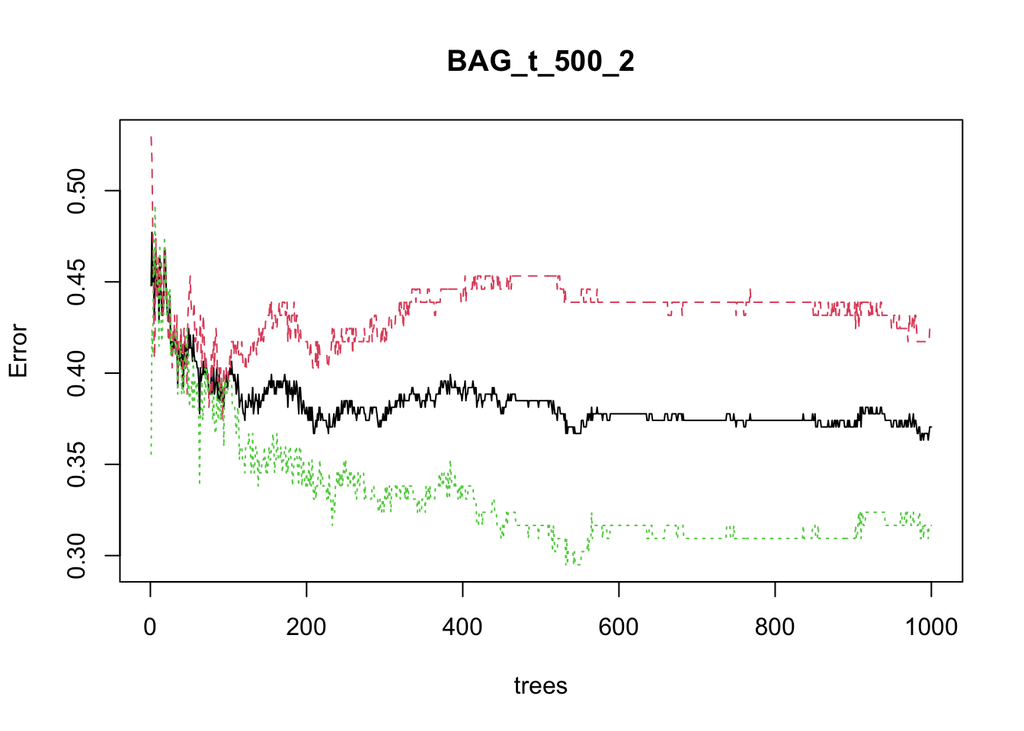

```r
base::plot(BAG_t_500_2)
```

```r
############################## optimal number of trees
(BAG_t_500_2$err.rate |> as.data.frame())$OOB |> which.min() # 986 trees
```

```
## [1] 986
```

# Tune RF with Training & Testing Split 500

```r
############################## find optimal mtry
set.seed(3)
# training set
Z_500 <- sample(nrow(lr_clr_df_500), .85*nrow(lr_clr_df_500)) # same as ridge/lasso 85 %
tuneRF(lr_clr_df_500[Z_500,-c(1,2)],
       lr_clr_df_500[Z_500,]$Clade, mtryStart = 2)
```

```
## mtry = 2  OOB error = 38.56%
## Searching left ...
## mtry = 1     OOB error = 44.49%
## -0.1538462 0.05
## Searching right ...
## mtry = 4     OOB error = 38.56%
## 0 0.05
```

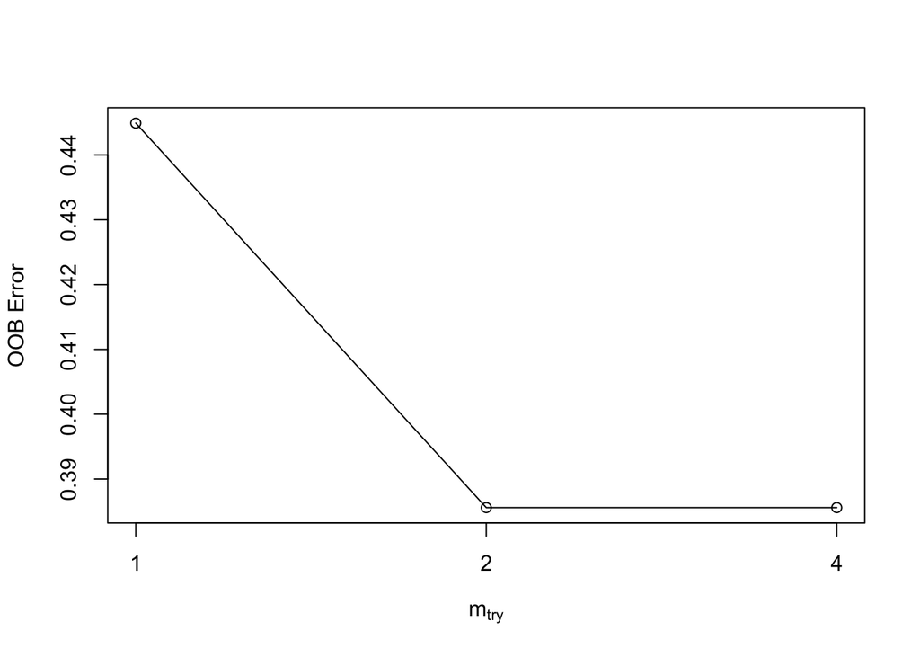

```
##       mtry  OOBError
## 1.OOB    1 0.4449153
## 2.OOB    2 0.3855932
## 4.OOB    4 0.3855932
```

### Re-run 500 with Optimal ntree and mtry

```r
set.seed(123)
BAG_500_o <- randomForest(Clade ~ . , # clade is already a factor
                     data = lr_clr_df_500[,-c(1)],
                     mtry = 2, # from above tuning
                     ntree = 986) # from above

BAG_500_o
```

```
##
## Call:
##  randomForest(formula = Clade ~ ., data = lr_clr_df_500[, -c(1)],      mtry = 2, ntree = 986)
##                Type of random forest: classification
##                      Number of trees: 986
## No. of variables tried at each split: 2
##
##         OOB estimate of  error rate: 37.05%
## Confusion matrix:
##    0   1 class.error
## 0 47  92  0.66187050
## 1 11 128  0.07913669
```

# Overall RandomForest Error Rates 1000, 500:

```r
BAG_500_o
```

```
##
## Call:
##  randomForest(formula = Clade ~ ., data = lr_clr_df_500[, -c(1)],      mtry = 2, ntree = 986)
##                Type of random forest: classification
##                      Number of trees: 986
## No. of variables tried at each split: 2
##
##         OOB estimate of  error rate: 37.05%
## Confusion matrix:
##    0   1 class.error
## 0 47  92  0.66187050
## 1 11 128  0.07913669
```

```r
BAG_1000_o
```

```
##
## Call:
##  randomForest(formula = lr_clr_df_1000$Clade ~ ., data = lr_clr_df_1000[,      -c(1, 2)], mtry = 2, ntree = 464)
##                Type of random forest: classification
##                      Number of trees: 464
## No. of variables tried at each split: 2
##
##         OOB estimate of  error rate: 36.69%
## Confusion matrix:
##    0   1 class.error
## 0 49  90  0.64748201
## 1 12 127  0.08633094
```

- Both optimized RandomForest models resulted in a 37 % error rate with the ‘mtry’ set at 2 variables. This may be due to the necessity of leaving the two species together, similar to K-means at times finding 2 clusters before the split of the data into separate species. Recall that the Clade C observations were n = 139, and they were kept together to increase the number of rows of data for modeling Clade C despite species.
- Also of note is that the individual class error rates for class 0 are worse than a coin toss (65-66 % errors).
- RandomForest modeling was chosen as an experiment to see if its non-parametric nature would model these data better than Ridge or Lasso classification. Ridge and Lasso have better error rates than RandomForest under the above seeds.
- Future research would attempt to increase the number of clade C observations in one species at a time with other non-clade C observations of equal number. Clade C was the 2nd most dominant Clade in the overall data. Clade A was the majority in terms of number of observations. See other analysis files in this directory, such as species split and files with ‘EDA’ in the titles.

# Boosted Trees

```r
library(gbm)
```

# Boosted 1000

```r
# gbm needs integer not factor
lr_clr_df_1000 %>%
  mutate(Clade = as.integer(Clade)-1) -> boost_data


set.seed(123)
boost_model_1000 <- gbm(boost_data[Z_1000,]$Clade ~ . ,
              data = boost_data[Z_1000, -c(1)],
              n.trees = 5000,
              distribution = "bernoulli") # logistic classification
boost_model_1000
```

```
## gbm(formula = boost_data[Z_1000, ]$Clade ~ ., distribution = "bernoulli",
##     data = boost_data[Z_1000, -c(1)], n.trees = 5000)
## A gradient boosted model with bernoulli loss function.
## 5000 iterations were performed.
## There were 1000 predictors of which 178 had non-zero influence.
```

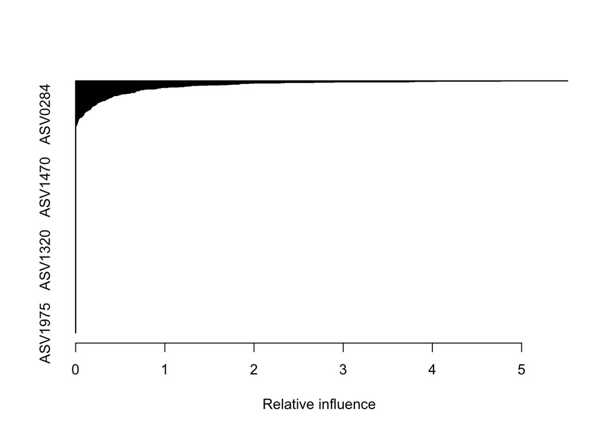

```
##               var    rel.inf
## ASV0074   ASV0074 5.51783685
## ASV0513   ASV0513 4.77366849
## ASV0185   ASV0185 4.03475399
## ASV0407   ASV0407 3.80305213
## ASV1113   ASV1113 3.74148533
## ASV0010   ASV0010 2.90027359
## ASV0768   ASV0768 2.67350089
## ASV0051   ASV0051 2.34133609
## ASV0187   ASV0187 2.29690184
## ASV0468   ASV0468 1.99315237
## ASV0295   ASV0295 1.93913057
## ASV0687   ASV0687 1.84606969
## ASV0055   ASV0055 1.83622129
## ASV0066   ASV0066 1.82746255
## ASV0065   ASV0065 1.74369205
## ASV0170   ASV0170 1.69625367
## ASV0384   ASV0384 1.61802265
## ASV0020   ASV0020 1.47558577
## ASV0411   ASV0411 1.37344403
## ASV0112   ASV0112 1.29356071
## ASV0164   ASV0164 1.29104986
## ASV0013   ASV0013 1.24639576
## ASV0034   ASV0034 1.21838369
## ASV0990   ASV0990 1.20916449
## ASV0004   ASV0004 1.15134174
## ASV0030   ASV0030 1.04089871
## ASV0035   ASV0035 1.03295360
## ASV0068   ASV0068 0.95491719
## ASV0044   ASV0044 0.95371147
## ASV0032   ASV0032 0.92296208
## ASV0001   ASV0001 0.92138426
## ASV0567   ASV0567 0.89846648
## ASV0177   ASV0177 0.88829707
## ASV0132   ASV0132 0.78744957
## ASV0027   ASV0027 0.76494647
## ASV0336   ASV0336 0.75875782
## ASV0157   ASV0157 0.72358794
## ASV0015   ASV0015 0.71938264
## ASV0200   ASV0200 0.71901065
```

[output cut: 946 more lines]

```
## ASV0226   ASV0226 0.00000000
## ASV12648 ASV12648 0.00000000
## ASV0204   ASV0204 0.00000000
## ASV0767   ASV0767 0.00000000
## ASV0335   ASV0335 0.00000000
## ASV5901   ASV5901 0.00000000
## ASV0596   ASV0596 0.00000000
## ASV9271   ASV9271 0.00000000
## ASV0904   ASV0904 0.00000000
## ASV15270 ASV15270 0.00000000
## ASV0155   ASV0155 0.00000000
## ASV0086   ASV0086 0.00000000
## ASV2581   ASV2581 0.00000000
## ASV7730   ASV7730 0.00000000
## ASV1975   ASV1975 0.00000000
```

```r
summary(boost_model_1000)
```

```r
pred_test_1000 = predict.gbm(object = boost_model_1000,
                   newdata = boost_data[-Z_1000, -c(1)], # 42 rows of testing
                   n.trees = 500,           # 500 tress to be built
                   type = "response")

pred_test_1000 # probabilities for bernoulli
```

```
##  [1] 0.4757979302 0.3212653927 0.1621616853 0.0658917792 0.4503711878
##  [6] 0.8662857030 0.8662857030 0.4895020063 0.0547451208 0.0726731846
## [11] 0.0008827238 0.6692054591 0.7523262683 0.9319755714 0.3194931242
## [16] 0.9130271677 0.1032450192 0.0454859302 0.0194426490 0.0191273519
## [21] 0.0550657024 0.0880258068 0.4578711473 0.8635127671 0.8629808707
## [26] 0.6944491443 0.6943151820 0.0487225341 0.9654609335 0.2100170003
## [31] 0.2214403768 0.5297929119 0.7893829500 0.1662461537 0.5678786868
## [36] 0.2093817349 0.4312894546 0.8256474759 0.8555249248 0.5436224969
## [41] 0.3542415881 0.2987697120
```

```r
# classes from above probabilities
as.data.frame(pred_test_1000) %>%
  mutate(actual_class = boost_data[-Z_1000, ]$Clade) %>% # y_train
  mutate(pred_class = ifelse(pred_test_1000 > 0.5, 1, 0)) -> pred_df

paste("Confusion Matrix Boosted Trees Model: ")
```

```
## [1] "Confusion Matrix Boosted Trees Model: "
```

```r
table(pred_df$actual_class,
      pred_df$pred_class)
```

```
##
##      0  1
##   0 16  5
##   1  9 12
```

```r
paste("Correct Classification Rate, Boosted Trees:  ")
```

```
## [1] "Correct Classification Rate, Boosted Trees:  "
```

```r
((16+12)/42)*100
```

```
## [1] 66.66667
```

# Boosted 500

```r
# gbm needs integer not factor
lr_clr_df_500 %>%
  mutate(Clade = as.integer(Clade)-1) -> boost_data_500


set.seed(123)
boost_model_500 <- gbm(boost_data_500[Z_500,]$Clade ~ . ,
              data = boost_data_500[Z_500, -c(1)],
              n.trees = 5000,
              distribution = "bernoulli") # logistic classification
boost_model_500
```

```
## gbm(formula = boost_data_500[Z_500, ]$Clade ~ ., distribution = "bernoulli",
##     data = boost_data_500[Z_500, -c(1)], n.trees = 5000)
## A gradient boosted model with bernoulli loss function.
## 5000 iterations were performed.
## There were 500 predictors of which 119 had non-zero influence.
```

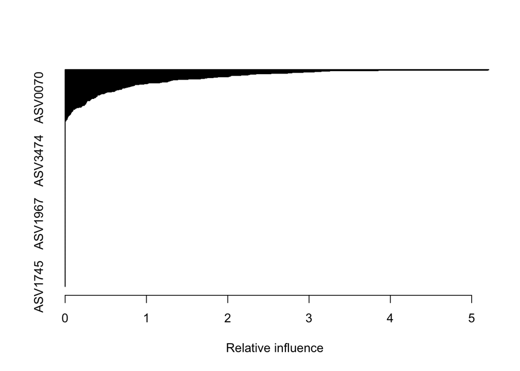

```
##               var     rel.inf
## ASV0407   ASV0407 5.211203465
## ASV0170   ASV0170 5.199179131
## ASV0032   ASV0032 3.851068247
## ASV0384   ASV0384 3.254785160
## ASV0185   ASV0185 3.148754654
## ASV0035   ASV0035 3.064822329
## ASV0006   ASV0006 2.927617347
## ASV0295   ASV0295 2.790128814
## ASV0066   ASV0066 2.735989464
## ASV0468   ASV0468 2.532436885
## ASV0065   ASV0065 2.347154329
## ASV0200   ASV0200 2.270673350
## ASV0411   ASV0411 2.250209740
## ASV0068   ASV0068 2.160811673
## ASV0172   ASV0172 2.039151387
## ASV0053   ASV0053 2.028180975
## ASV0003   ASV0003 2.009479870
## ASV0055   ASV0055 1.875049701
## ASV0023   ASV0023 1.822070779
## ASV0072   ASV0072 1.743469862
## ASV0034   ASV0034 1.713801745
## ASV0011   ASV0011 1.664854310
## ASV0157   ASV0157 1.512202417
## ASV0129   ASV0129 1.384817893
## ASV0004   ASV0004 1.323064216
## ASV0024   ASV0024 1.302564078
## ASV0013   ASV0013 1.286361678
## ASV0001   ASV0001 1.268668003
## ASV0135   ASV0135 1.257858516
## ASV0521   ASV0521 1.186178966
## ASV0078   ASV0078 1.163377623
## ASV0052   ASV0052 1.024330505
## ASV0567   ASV0567 1.011208395
## ASV0007   ASV0007 0.969420969
## ASV1072   ASV1072 0.908489137
## ASV0009   ASV0009 0.855670809
## ASV0336   ASV0336 0.853304650
## ASV0116   ASV0116 0.836378888
## ASV0059   ASV0059 0.812882035
```

[output cut: 446 more lines]

```
## ASV2495   ASV2495 0.000000000
## ASV5582   ASV5582 0.000000000
## ASV1488   ASV1488 0.000000000
## ASV1987   ASV1987 0.000000000
## ASV7192   ASV7192 0.000000000
## ASV0873   ASV0873 0.000000000
## ASV4749   ASV4749 0.000000000
## ASV2174   ASV2174 0.000000000
## ASV1476   ASV1476 0.000000000
## ASV0740   ASV0740 0.000000000
## ASV2466   ASV2466 0.000000000
## ASV1709   ASV1709 0.000000000
## ASV6170   ASV6170 0.000000000
## ASV3673   ASV3673 0.000000000
## ASV1745   ASV1745 0.000000000
```

```r
summary(boost_model_500)
```

```r
pred_test_500 = predict.gbm(object = boost_model_500,
                   newdata = boost_data_500[-Z_500, -c(1)], # 42 rows of testing
                   n.trees = 500,           # 500 tress to be built
                   type = "response")

pred_test_500 # probabilities for bernoulli
```

```
##  [1] 0.6667767730 0.8208697300 0.0773065330 0.2270393417 0.4182649097
##  [6] 0.7919212162 0.7919212162 0.4962084749 0.1469481166 0.0797406395
## [11] 0.0002639169 0.4070227107 0.1113942381 0.8890545515 0.3147522544
## [16] 0.9672551305 0.1577693052 0.0127847244 0.1845888302 0.1492650781
## [21] 0.3148455279 0.0150157913 0.4714955305 0.8638702523 0.5821124714
## [26] 0.7165015368 0.4164369316 0.0101120102 0.8976490688 0.0211022202
## [31] 0.2995327573 0.3833295446 0.8429237338 0.1285212113 0.6923694659
## [36] 0.2560558561 0.4472253297 0.7813446661 0.6701616823 0.3636650040
## [41] 0.2325729321 0.3201103173
```

```r
# classes from above probabilities
as.data.frame(pred_test_500) %>%
  mutate(actual_class = boost_data[-Z_500, ]$Clade) %>% # y_train
  mutate(pred_class = ifelse(pred_test_500 > 0.5, 1, 0)) -> pred_500_df

paste("Confusion Matrix Boosted Trees Model: ")
```

```
## [1] "Confusion Matrix Boosted Trees Model: "
```

```r
table(pred_500_df$actual_class,
      pred_500_df$pred_class)
```

```
##
##      0  1
##   0 16  5
##   1 12  9
```

```r
paste("Correct Classification Rate, 500 ASVs, Boosted Trees:  ")
```

```
## [1] "Correct Classification Rate, 500 ASVs, Boosted Trees:  "
```

```r
((16+9)/42)*100
```

```
## [1] 59.52381
```